# Model ARIMA - Tugas Praktikum 7

Bryant Indervil Deadora G1401231062

# Import Packages

```r
library(rio)
library(tidyverse)
library(ggplot2)
library(tsibble)
library(tseries)
library(MASS)
library(forecast)
library(TSA)
```

# Import Data

```r
df <- import("https://raw.githubusercontent.com/bryantddr/mpdw/refs/heads/main/Pertemuan%202/Bitcoin.csv")
df <- df %>%
  mutate(
    Price = gsub(pattern = ",", replacement = "", x = Price),
    Price = as.numeric(Price),
    Price = Price/1000)
dt <- df[379:504,2]
ts.dt <- ts(dt)
```

# Splitting Data

```r
dt.train <- dt[1:floor(0.8*length(dt))]
dt.test <- dt[(floor(0.8*length(dt))+1): length(dt)]
```

```r
ts.dt.train <- ts(dt.train)
ts.dt.test <- ts(dt.test)
```

# Ekplorasi Data

## Plot Time Series

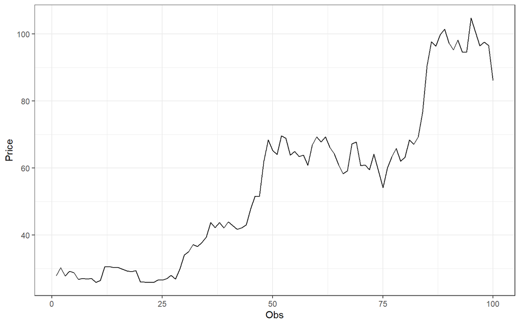

```r
plot_df <- ts.dt.train |> as_tsibble() |>
  ggplot(aes(x = index, y = value)) + geom_line() + theme_bw() +
  xlab("Obs") + ylab("Price")
plot_df
```

```r
mean(ts.dt.train)
```

```
## [1] 55.03553
```

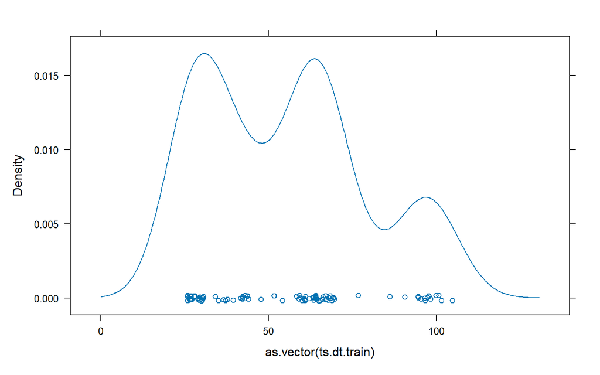

```r
lattice::densityplot(as.vector(ts.dt.train))
```

Berdasarkan plot, terlihat data tidak stasioner dalam rataan maupun ragam, ditandai data tidak menyebar di sekitar nilai tengahnya, cenderung adanya tren.

## Plot ACF

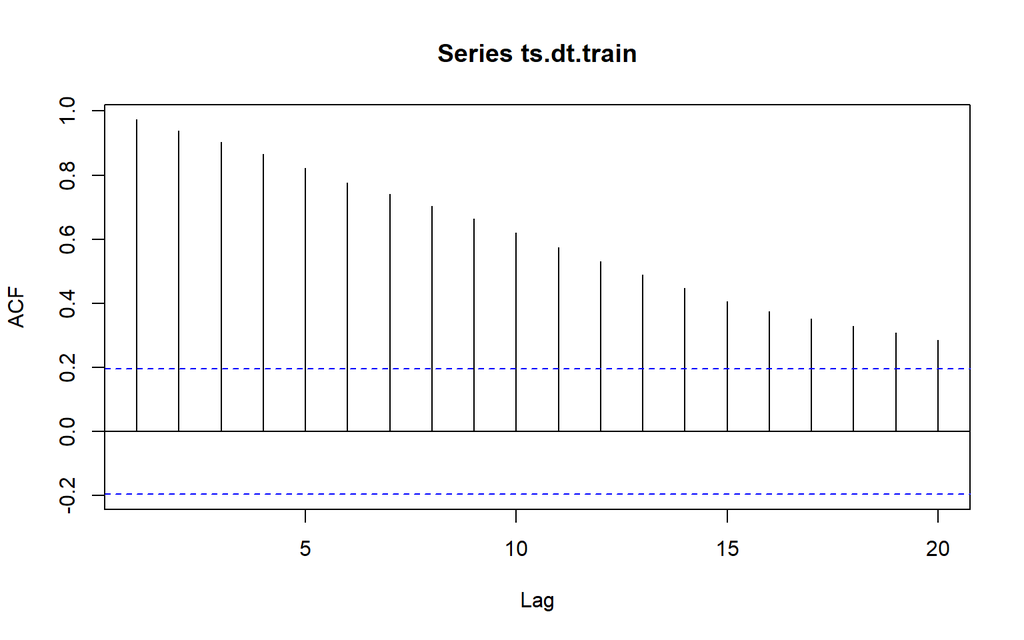

```r
acf(ts.dt.train)
```

Berdasarkan plot ACF, terlihat plot tails off slowly. Hal ini mengindikasikan terdapat tidak stationer dalam rataan.

## Uji ADF

```r
adf.test(ts.dt.train)
```

```
##
##  Augmented Dickey-Fuller Test
##
## data:  ts.dt.train
## Dickey-Fuller = -3.1255, Lag order = 4, p-value = 0.1104
## alternative hypothesis: stationary
```

$H_0$ : Data tidak stasioner dalam rataan $H_1$ : Data stasioner dalam rataan

Berdasarkan hasil uji ADF, *p-value* = 0.1104 > 0.05 = $\alpha$, maka tak tolak $H_0$. Data tidak stasioner dalam rataan. Hal ini sesuai dengan *time series* dan ACF plot.

Dalam data ekonomi termasuk Bitcoin, hal ini hampir pasti terjadi. Oleh karena itu, akan dilakukan pengananan lebih lanjut.

## Uji Box-Cox

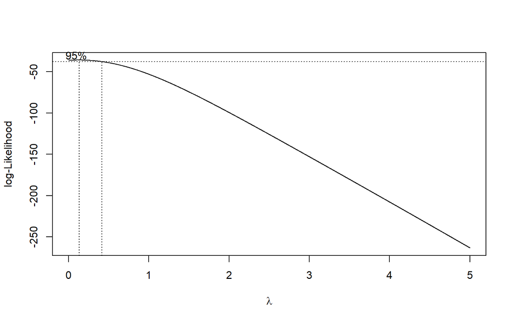

```r
index <- seq(1:100)

# Uji Box-Cox
bc <- boxcox(
  ts.dt.train  ~ index,
  lambda = seq(0, 5, by = 0.001)
)
```

```r
lambda <- bc$x[which.max(bc$y)]
lambda
```

```
## [1] 0.132
```

```r
# Selang kepercayaan 95% untuk lambda
ci_lambda <- bc$x[bc$y > max(bc$y) - 0.5 * qchisq(0.95, 1)]

# Batas bawah dan batas atas
ci_lower <- min(ci_lambda)
ci_upper <- max(ci_lambda)

c(Batas_Bawah = ci_lower, Batas_Atas = ci_upper)
```

```
## Batas_Bawah  Batas_Atas
##       0.000       0.414
```

Hasil uji Box-Cox menunjukkan bahwa nilai $\lambda$ optimum adalah 0.132 dengan interval kepercayaan 95% (0,0.414). Selang tidak mengandung $\lambda$ = 1, maka data tidak stasioner dalam ragam.

# Penanganan Ketidakstasioneran

# Differencing

```r
ts.dt.train_diff1 <- diff(ts.dt.train, differences = 1)
```

# Plot Time Series

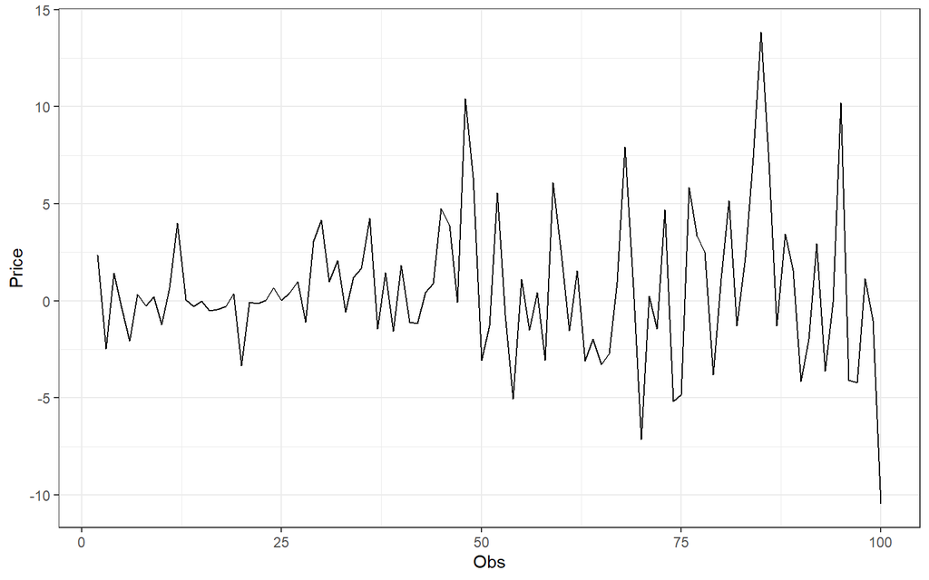

```r
plot_dt.train_diff1 <- ts.dt.train_diff1 |> as_tsibble() |>
  ggplot(aes(x = index, y = value)) + geom_line() + theme_bw() +
  xlab("Obs") + ylab("Price")
plot_dt.train_diff1
```

Berdasarkan plot, data terlihat menyebar pada rataan yang berarti stasioner pada rataan. Namun, sekilas terlihat belum stasioner pada ragam.

### Plot ACF

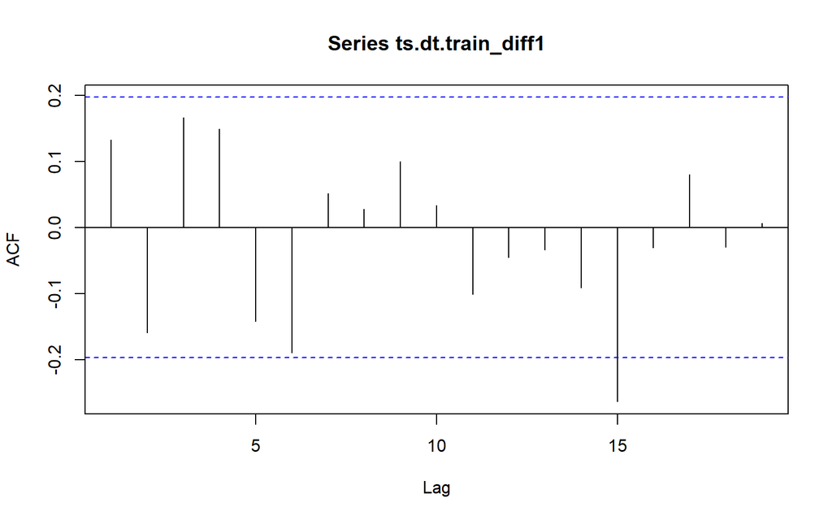

```r
acf(ts.dt.train_diff1)
```

Berdasarkan Plot ACF, terlihat sudah stasioner dalam rataan. Hasil ini sama dengan time series plot.

### Uji ADF

```r
adf.test(ts.dt.train_diff1)
```

```
##
##  Augmented Dickey-Fuller Test
##
## data:  ts.dt.train_diff1
## Dickey-Fuller = -3.6175, Lag order = 4, p-value = 0.03526
## alternative hypothesis: stationary
```

$H_0$ : Data tidak stasioner dalam rataan $H_1$ : Data stasioner dalam rataan

Berdasarkan uji ADF, *p-value* = 0.035 < 0.05 = $\alpha$, tolak H0. Data sudah stasioner pada rataan, sesuai dengan hasil dari *time series plot* dan plot ACF

### Uji Box-Cox

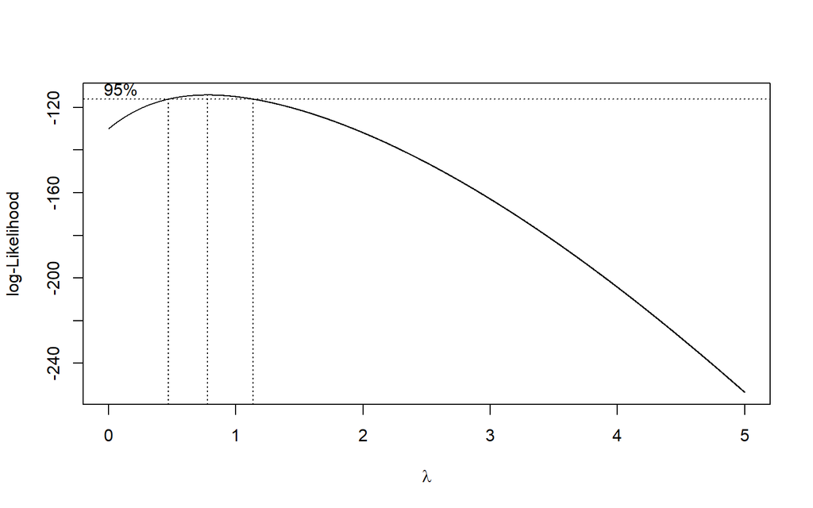

```r
index <- seq(1:99)

# Uji Box-Cox
bc <- boxcox(
  ts.dt.train_diff1 - min(ts.dt.train_diff1) + 1  ~ index,
  lambda = seq(0, 5, by = 0.001)
)
```

```r
# Selang kepercayaan 95% untuk lambda
ci_lambda <- bc$x[bc$y > max(bc$y) - 0.5 * qchisq(0.95, 1)]

# Batas bawah dan batas atas
ci_lower <- min(ci_lambda)
ci_upper <- max(ci_lambda)

c(Batas_Bawah = ci_lower, Batas_Atas = ci_upper)
```

```
## Batas_Bawah  Batas_Atas
##       0.471       1.133
```

Berdasarkan Uji Box-Cox, interval kepercayaan 95% $\lambda$ sebesar (0.471,1.133). Dalam selang ini terdapat nilai $\lambda$ = 1, maka data sudah stasioner dalam ragam.

# Identifikasi Model

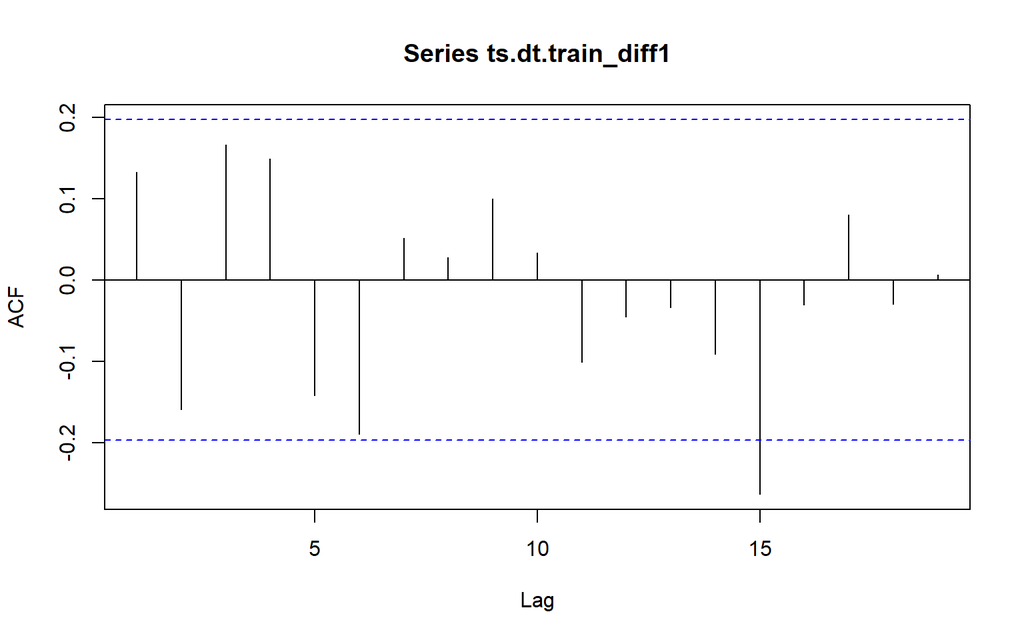

```r
acf(ts.dt.train_diff1)
```

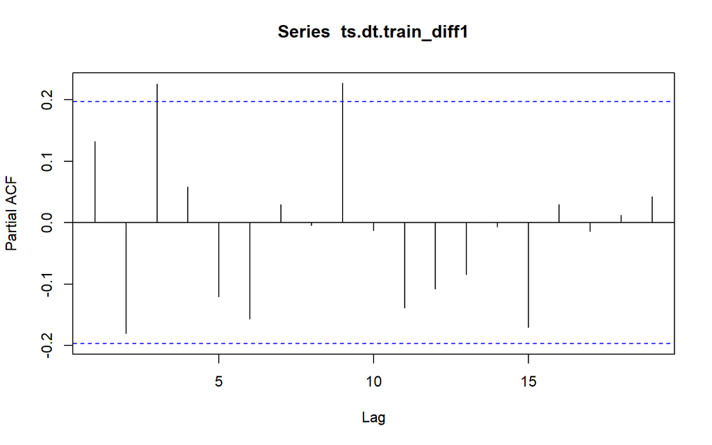

```r
pacf(ts.dt.train_diff1)
```

```r
eacf(ts.dt.train_diff1)
```

```
## AR/MA
##   0 1 2 3 4 5 6 7 8 9 10 11 12 13
## 0 o o o o o o o o o o o  o  o  o
## 1 x o o o o o o o o o o  o  o  o
## 2 x o o o o o o o o o o  o  o  o
## 3 x x x o o o o o o o o  o  o  o
## 4 x x o o o o o o o o o  o  o  o
## 5 x x x o o o o o o o o  o  o  o
## 6 x o x o o o o o o o o  o  o  o
## 7 x o x x o x o o o o o  o  o  o
```

Identifikasi model menggunakan plot EACF dilakukan dengan melihat ujung segitiga pada pola segitiga nol. Dalam hal ini model tentatif yang terbentuk adalah ARIMA(1,1,1), ARIMA(1,1,2)

# Pendugaan Parameter Model Tentatif

```r
model1.da=Arima(ts.dt.train_diff1, order=c(0,0,1),method="ML")
summary(model1.da)
```

```
## Series: ts.dt.train_diff1
## ARIMA(0,0,1) with non-zero mean
##
## Coefficients:
##          ma1    mean
##       0.2727  0.5657
## s.e.  0.1399  0.4594
##
## sigma^2 = 13.22:  log likelihood = -267.29
## AIC=540.59   AICc=540.84   BIC=548.37
##
## Training set error measures:
##                       ME     RMSE      MAE       MPE     MAPE      MASE
## Training set -0.00618377 3.598792 2.671199 -125.3989 390.0462 0.7293513
##                     ACF1
## Training set -0.05725237
```

```r
lmtest::coeftest(model1.da)
```

```
##
## z test of coefficients:
##
##           Estimate Std. Error z value Pr(>|z|)
## ma1        0.27271    0.13985  1.9500  0.05118 .
## intercept  0.56566    0.45942  1.2313  0.21823
## ---
## Signif. codes:  0 '***' 0.001 '**' 0.01 '*' 0.05 '.' 0.1 ' ' 1
```

```r
model2.da=Arima(ts.dt.train_diff1, order=c(1,0,0),method="ML")
summary(model2.da)
```

```
## Series: ts.dt.train_diff1
## ARIMA(1,0,0) with non-zero mean
##
## Coefficients:
##          ar1    mean
##       0.1447  0.5713
## s.e.  0.1040  0.4259
##
## sigma^2 = 13.44:  log likelihood = -268.09
## AIC=542.19   AICc=542.44   BIC=549.97
##
## Training set error measures:
##                        ME     RMSE      MAE       MPE     MAPE     MASE
## Training set -0.002801547 3.629047 2.657252 -119.2928 364.4069 0.725543
##                    ACF1
## Training set 0.02724195
```

```r
lmtest::coeftest(model2.da)
```

```
##
## z test of coefficients:
##
##           Estimate Std. Error z value Pr(>|z|)
## ar1        0.14469    0.10401  1.3911   0.1642
## intercept  0.57134    0.42591  1.3414   0.1798
```

```r
model3.da=Arima(ts.dt.train_diff1, order=c(1,0,1),method="ML")
summary(model3.da)
```

```
## Series: ts.dt.train_diff1
## ARIMA(1,0,1) with non-zero mean
##
## Coefficients:
##           ar1     ma1    mean
##       -0.5581  0.8157  0.5755
## s.e.   0.1906  0.1378  0.4111
##
## sigma^2 = 12.73:  log likelihood = -265
## AIC=538   AICc=538.42   BIC=548.38
##
## Training set error measures:
##                        ME     RMSE      MAE       MPE     MAPE      MASE
## Training set -0.005849399 3.513206 2.564124 -257.6991 511.5398 0.7001151
##                     ACF1
## Training set -0.02591978
```

```r
lmtest::coeftest(model3.da)
```

```
##
## z test of coefficients:
##
##           Estimate Std. Error z value  Pr(>|z|)
## ar1       -0.55811    0.19055 -2.9289  0.003402 **
## ma1        0.81567    0.13778  5.9199 3.222e-09 ***
## intercept  0.57547    0.41111  1.3998  0.161575
## ---
## Signif. codes:  0 '***' 0.001 '**' 0.01 '*' 0.05 '.' 0.1 ' ' 1
```

```r
model4.da=Arima(ts.dt.train_diff1, order=c(1,0,2),method="ML")
summary(model4.da)
```

```
## Series: ts.dt.train_diff1
## ARIMA(1,0,2) with non-zero mean
##
## Coefficients:
##           ar1     ma1      ma2    mean
##       -0.3750  0.6050  -0.1122  0.5852
## s.e.   0.3653  0.3627   0.1568  0.3830
##
## sigma^2 = 12.81:  log likelihood = -264.79
## AIC=539.59   AICc=540.23   BIC=552.56
##
## Training set error measures:
##                        ME     RMSE      MAE       MPE     MAPE      MASE
## Training set -0.005796998 3.506118 2.549113 -294.6551 537.0114 0.6960164
##                      ACF1
## Training set -0.002118229
```

```r
lmtest::coeftest(model4.da)
```

```
##
## z test of coefficients:
##
##           Estimate Std. Error z value Pr(>|z|)
## ar1       -0.37498    0.36530 -1.0265  0.30465
## ma1        0.60500    0.36271  1.6680  0.09531 .
## ma2       -0.11215    0.15681 -0.7152  0.47448
## intercept  0.58521    0.38299  1.5280  0.12651
## ---
## Signif. codes:  0 '***' 0.001 '**' 0.01 '*' 0.05 '.' 0.1 ' ' 1
```

```r
model5.da=Arima(ts.dt.train_diff1, order=c(2,0,2),method="ML")
summary(model5.da)
```

```
## Series: ts.dt.train_diff1
## ARIMA(2,0,2) with non-zero mean
##
## Coefficients:
##           ar1      ar2     ma1     ma2    mean
##       -0.6280  -0.8234  0.7963  0.7390  0.6044
## s.e.   0.2227   0.1346  0.2471  0.2012  0.3585
##
## sigma^2 = 12.51:  log likelihood = -263.27
## AIC=538.53   AICc=539.44   BIC=554.1
##
## Training set error measures:
##                        ME     RMSE      MAE       MPE     MAPE      MASE
## Training set -0.005100939 3.446697 2.574043 -319.3871 576.9665 0.7028234
##                    ACF1
## Training set 0.04405657
```

```r
lmtest::coeftest(model5.da)
```

```
##
## z test of coefficients:
##
##           Estimate Std. Error z value  Pr(>|z|)
## ar1       -0.62796    0.22271 -2.8196 0.0048079 **
## ar2       -0.82339    0.13465 -6.1151 9.648e-10 ***
## ma1        0.79628    0.24708  3.2228 0.0012694 **
## ma2        0.73901    0.20117  3.6736 0.0002392 ***
## intercept  0.60442    0.35850  1.6860 0.0917960 .
## ---
## Signif. codes:  0 '***' 0.001 '**' 0.01 '*' 0.05 '.' 0.1 ' ' 1
```

# Ringkasan AIC

```r
model_tentatif <- data.frame(
  Model = c("ARIMA(0,0,1)","ARIMA(1,0,0)","ARIMA(1,0,1)", "ARIMA(1,0,2)",
            "ARIMA(2,0,2)"),
  AIC   = c(AIC(model1.da),AIC(model2.da), AIC(model3.da), AIC(model4.da), AIC(model5.da)),
  BIC   = c(BIC(model1.da),BIC(model2.da), BIC(model3.da), BIC(model4.da), BIC(model5.da))
)

model_tentatif
```

| Model | AIC | BIC |
| --- | --- | --- |
| ARIMA(0,0,1) | 540.5855 | 548.3709 |
| ARIMA(1,0,0) | 542.1871 | 549.9724 |
| ARIMA(1,0,1) | 537.9956 | 548.3761 |
| ARIMA(1,0,2) | 539.5880 | 552.5636 |
| ARIMA(2,0,2) | 538.5315 | 554.1023 |

# Analisis Sisaan

## Ekplorasi Sisaan

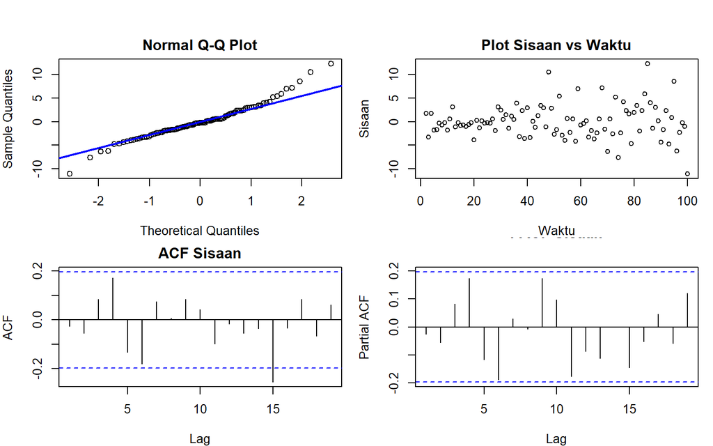

```r
sisaan.da <- model3.da$residuals

par(mfrow = c(2,2),
    mar = c(4,4,2,1),
    oma = c(0,0,2,0))

# Q-Q Plot
qqnorm(sisaan.da, main = "Normal Q-Q Plot")
qqline(sisaan.da, col = "blue", lwd = 2)

# Plot Sisaan vs Waktu
plot(sisaan.da, type = "p",
     main = "Plot Sisaan vs Waktu",
     xlab = "Waktu", ylab = "Sisaan")

# ACF
acf(sisaan.da, main = "ACF Sisaan")

# PACF
pacf(sisaan.da, main = "PACF Sisaan")
```

## Uji Formal

```r
ks.test(sisaan.da,"pnorm")
```

```
##
##  Exact one-sample Kolmogorov-Smirnov test
##
## data:  sisaan.da
## D = 0.26971, p-value = 7.506e-07
## alternative hypothesis: two-sided
```

$H_0$: Sisaan menyebar normal $H_1$: Sisaan tidak menyebar normal

Berdasarkan uji KS tersebut, didapat p-value sebesar $7.506 \times 10^{-7}$ yang kurang dari taraf nyata 5% sehingga tolak dan menandakan bahwa sisaan tidak menyebar normal. Hal ini tidak sesuai dengan hasil eksplorasi menggunakan plot kuantil-kuantil normal.

```r
Box.test(sisaan.da, type = "Ljung")
```

```
##
##  Box-Ljung test
##
## data:  sisaan.da
## X-squared = 0.068548, df = 1, p-value = 0.7935
```

$H_0$: Sisaan saling bebas $H_1$: Sisaan tidak saling bebas

Berdasarkan uji Ljung-Box tersebut, didapat p-value sebesar 0.7935 yang lebih besar dari taraf nyata 5% sehingga gagal tolak $H_0$ dan menandakan bahwa sisaan saling bebas. Hal ini berbeda dengan eksplorasi.

```r
Box.test((sisaan.da)^2, type = "Ljung")
```

```
##
##  Box-Ljung test
##
## data:  (sisaan.da)^2
## X-squared = 0.40354, df = 1, p-value = 0.5253
```

$H_0$: Ragam sisaan homogen $H_1$: Ragam sisaan tidak homogen

Berdasarkan uji Ljung-Box terhadap sisaan kuadrat tersebut, didapat p-value sebesar 0.5253 yang lebih besar dari taraf nyata 5% sehingga gagal tolak $H_0$ dan menandakan bahwa ragam sisaan homogen.

```r
t.test(sisaan.da, mu = 0, conf.level = 0.95)
```

```
##
##  One Sample t-test
##
## data:  sisaan.da
## t = -0.016482, df = 98, p-value = 0.9869
## alternative hypothesis: true mean is not equal to 0
## 95 percent confidence interval:
##  -0.7101110  0.6984122
## sample estimates:
##    mean of x
## -0.005849399
```

$H_0$: Nilai tengah sisaan sama dengan 0 $H_1$: Nilai tengah sisaan tidak sama dengan 0

Berdasarkan uji-t, didapat p-value sebesar 0.9869 yang lebih besar dari taraf nyata 5% sehingga gagal tolak $H_0$ dan menandakan bahwa nilai tengah sisaan sama dengan nol.

# Model Terbaik

```r
model3.da
```

```
## Series: ts.dt.train_diff1
## ARIMA(1,0,1) with non-zero mean
##
## Coefficients:
##           ar1     ma1    mean
##       -0.5581  0.8157  0.5755
## s.e.   0.1906  0.1378  0.4111
##
## sigma^2 = 12.73:  log likelihood = -265
## AIC=538   AICc=538.42   BIC=548.38
```

```r
lmtest::coeftest(model3.da)
```

```
##
## z test of coefficients:
##
##           Estimate Std. Error z value  Pr(>|z|)
## ar1       -0.55811    0.19055 -2.9289  0.003402 **
## ma1        0.81567    0.13778  5.9199 3.222e-09 ***
## intercept  0.57547    0.41111  1.3998  0.161575
## ---
## Signif. codes:  0 '***' 0.001 '**' 0.01 '*' 0.05 '.' 0.1 ' ' 1
```

# Peramalan

Peramalan dilakukan untuk 26 hari ke depan

```r
ramalan.da <- forecast(model3.da, h = length(ts.dt.test))
```

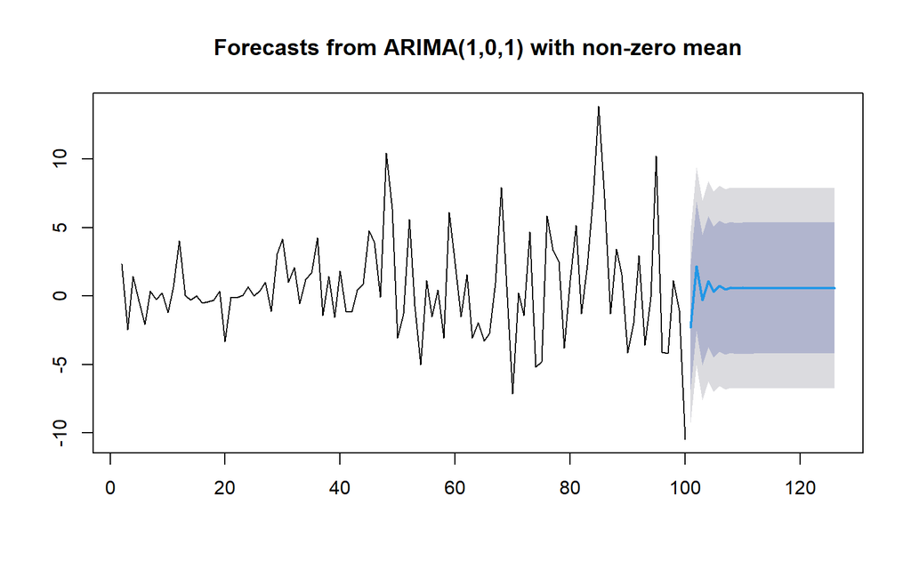

```r
dt.ramalan.da <- ramalan.da$mean
plot(ramalan.da)
```

```r
pt_akhir_train <- tail(ts.dt.test, 1)

forecast <- diffinv(dt.ramalan.da, differences = 1, xi = pt_akhir_train)
hasil <- forecast[-1]
hasil <- forecast[1:length(ts.dt.test)]

# Bandingkan aktual vs forecast
perbandingan.da <- cbind(
  Aktual   = ts.dt.test,
  Forecast = hasil
)

print(head(perbandingan.da, 10))
```

```
## Time Series:
## Start = 1
## End = 10
## Frequency = 1
##      Aktual Forecast
##  1  86.2219 110.4039
##  2  84.3413 108.1182
##  3  83.8405 110.2905
##  4  82.6457 109.9748
##  5  83.5521 111.0476
##  6  85.2927 111.3455
##  7  85.0681 112.0759
##  8  94.6314 112.5649
##  9  95.8858 113.1886
## 10 104.7980 113.7371
```

```r
akurasi_test <- accuracy(hasil, ts.dt.test)
akurasi_test
```

```
##                 ME     RMSE      MAE       MPE     MAPE      ACF1 Theil's U
## Test set -13.65954 16.11877 13.65954 -14.64868 14.64868 0.8665106  4.307687
```

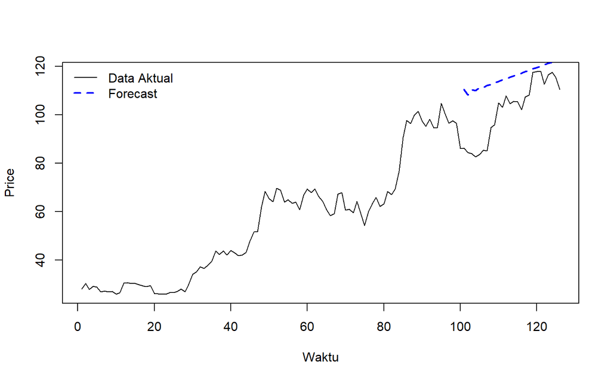

```r
ts.plot(ts.dt, col = "black", lty = 1,
        xlab = "Waktu", ylab = "Price")

# Garis forecast
lines(101:(100+length(hasil)), hasil, col = "blue", lty = 2, lwd = 2)
legend("topleft",
       legend = c("Data Aktual", "Forecast"),
       col = c("black", "blue"),
       lty = c(1,2,3), lwd = c(1,2,1), bty = "n")
```

```r
length(hasil)
```

```
## [1] 26
```